# Notebook

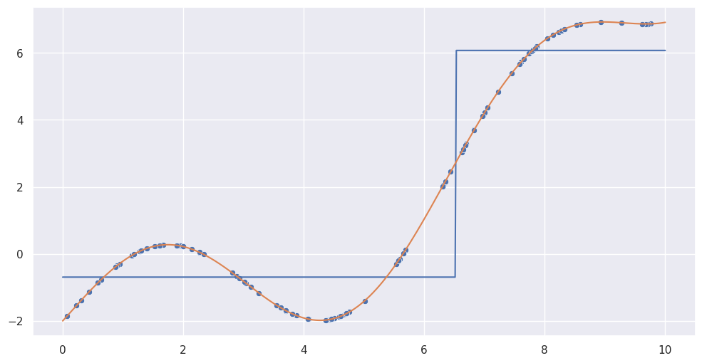

```
No randomness:      MAE = 0.91, MSE = 1.17, RMSE = 1.08
```

```python
dt1_mae = evaluate_non_random_regressor(
    DecisionTreeRegressor, fun, max_depth=1, criterion="absolute_error"
)
```

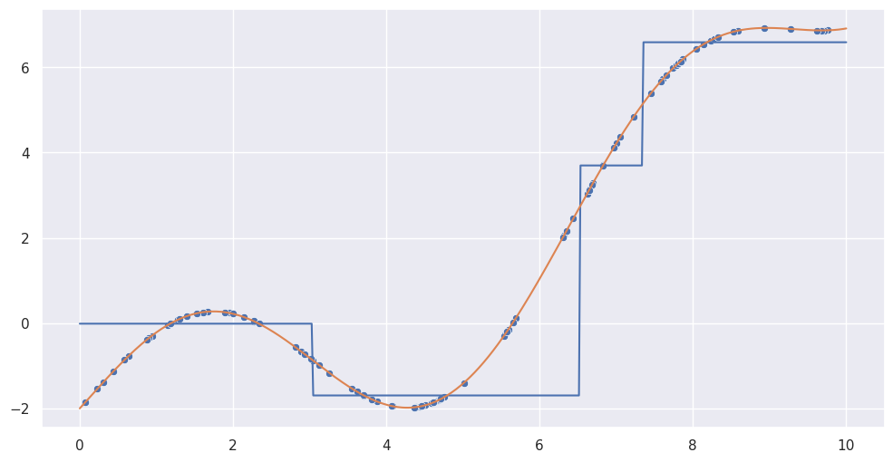

```
No randomness:      MAE = 0.80, MSE = 1.50, RMSE = 1.22
```

```python
dt2_mae = evaluate_non_random_regressor(
    DecisionTreeRegressor, fun, max_depth=2, criterion="absolute_error"
)
```

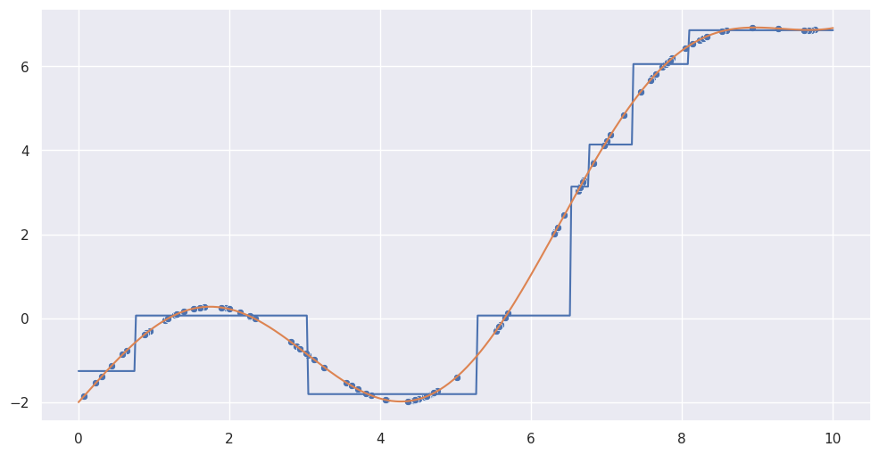

```
No randomness:      MAE = 0.36, MSE = 0.33, RMSE = 0.57
```

```python
dt3_mae = evaluate_non_random_regressor(
    DecisionTreeRegressor, fun, max_depth=3, criterion="absolute_error"
);
```

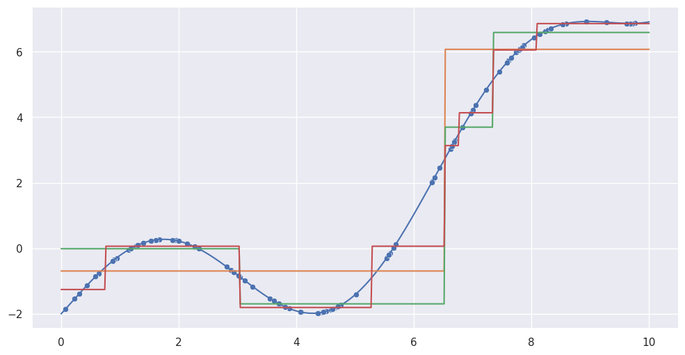

```python
plot_regressions([dt1_mae, dt2_mae, dt3_mae], fun)
```

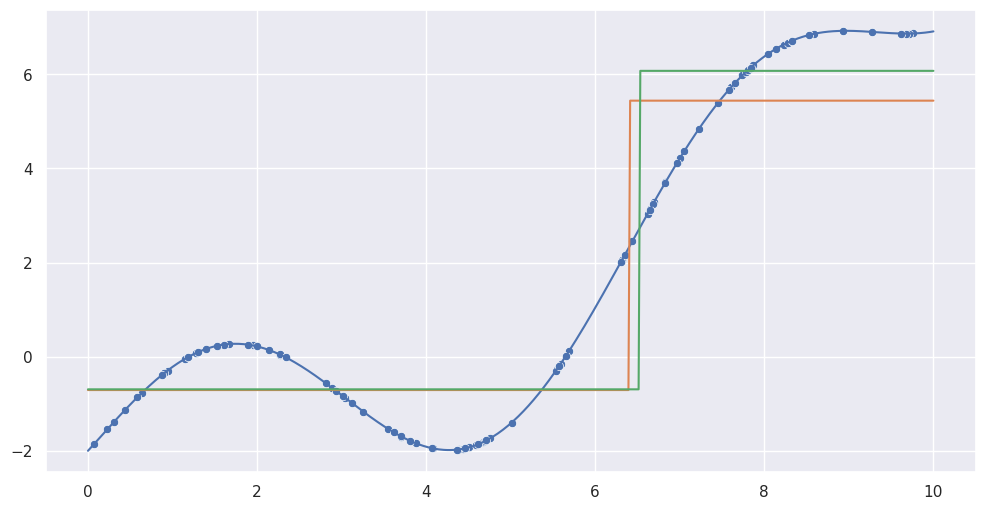

```python
plot_regressions([dt1, dt1_mae], fun)
```

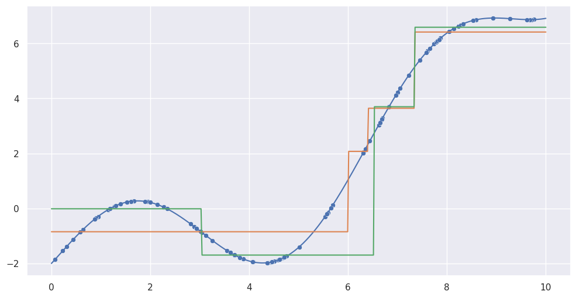

```python
plot_regressions([dt2, dt2_mae], fun)
```

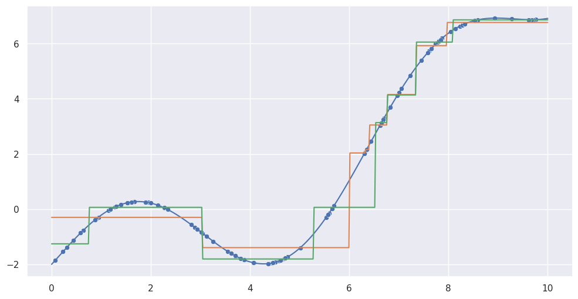

```python
plot_regressions([dt3, dt3_mae], fun)
```

```python
def plot_graphs(f_y, reg, reg_rand, reg_chaos, y_train, y_rand_train, y_chaos_train):
    x_plot = np.linspace(0, 10, 500).reshape(-1, 1)
    fig, ax = plt.subplots(figsize=(12, 8))
    sns.lineplot(x=x_plot[:, 0], y=reg.predict(x_plot), ax=ax)
    sns.scatterplot(x=x_train[:, 0], y=y_train, ax=ax)

    sns.lineplot(x=x_plot[:, 0], y=reg_rand.predict(x_plot), ax=ax)
    sns.scatterplot(x=x_train[:, 0], y=y_rand_train, ax=ax)

    sns.lineplot(x=x_plot[:, 0], y=reg_chaos.predict(x_plot), ax=ax)
    sns.scatterplot(x=x_train[:, 0], y=y_chaos_train, ax=ax)

    sns.lineplot(x=x_plot[:, 0], y=f_y(x_plot[:, 0]), ax=ax)
    plt.show()
```

```python
def evaluate_regressor(reg_type, f_y, *args, **kwargs):
    reg = reg_type(*args, **kwargs)
    reg_rand = reg_type(*args, **kwargs)
    reg_chaos = reg_type(*args, **kwargs)

    y_train = f_y(x_train).reshape(-1)
    y_test = f_y(x_test).reshape(-1)
    y_pred = reg.fit(x_train, y_train).predict(x_test)

    y_rand_train = randomize(f_y, x_train).reshape(-1)
    y_rand_test = randomize(f_y, x_test).reshape(-1)
    y_rand_pred = reg_rand.fit(x_train, y_rand_train).predict(x_test)

    y_chaos_train = randomize(f_y, x_train, 1.5).reshape(-1)
    y_chaos_test = randomize(f_y, x_test, 1.5).reshape(-1)
    y_chaos_pred = reg_chaos.fit(x_train, y_chaos_train).predict(x_test)

    plot_graphs(f_y, reg, reg_rand, reg_chaos, y_train, y_rand_train, y_chaos_train)
    print_evaluation(y_test, y_pred, y_rand_test, y_rand_pred, y_chaos_test, y_chaos_pred)
```

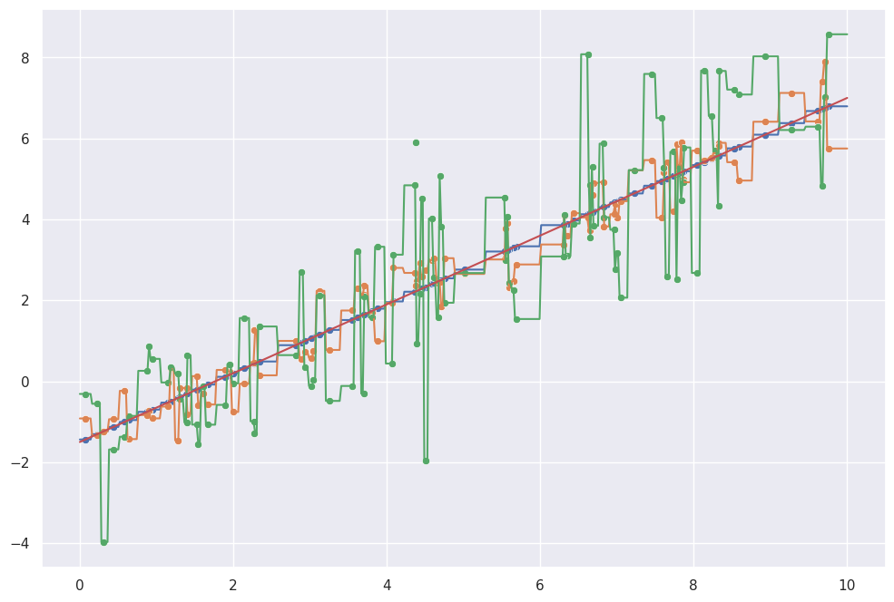

```
No randomness:      MAE = 0.05, MSE = 0.01, RMSE = 0.07
Some randomness:    MAE = 0.60, MSE = 0.57, RMSE = 0.75
Lots of randomness: MAE = 1.74, MSE = 4.63, RMSE = 2.15
```

```python
evaluate_regressor(DecisionTreeRegressor, lin)
```

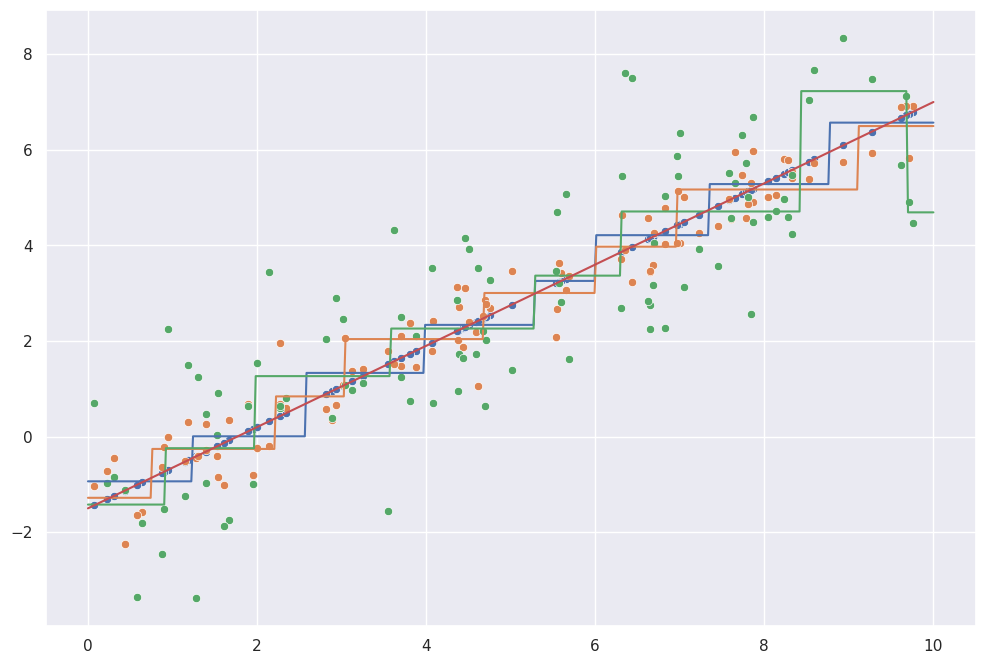

```
No randomness:      MAE = 0.24, MSE = 0.08, RMSE = 0.29
Some randomness:    MAE = 0.59, MSE = 0.56, RMSE = 0.75
Lots of randomness: MAE = 1.16, MSE = 2.15, RMSE = 1.47
```

```python
evaluate_regressor(DecisionTreeRegressor, lin, max_depth=3)
```

# Overfitting and Underfitting

Overfitting occurs when the model matches noise in the training data.

Underfitting occurs when the model cannot match the training data set.

## Bias/Variance Tradeoff

**Bias error:** Error from bad assumptions in our model or learning algorithm about the structure of our solution. Leads to underfitting.

**Variance:** Reaction to small fluctuations in the training data. Leads to overfitting.

"[B]ias measures the tendency of a system to consistently learn the wrong things, and variance measures its tendency to learn irrelevant details"

-- Pedro Domingos

### Bias/Variance Tradeoff

[figure not shown]

```python
x = np.linspace(0, 10, 500)
y = randomize(fun, x, 2.0)
lr_reg = LinearRegression().fit(x.reshape(-1, 1), y)
dt_reg = DecisionTreeRegressor().fit(x.reshape(-1, 1), y)

def plot(reg, ax):
    sns.lineplot(x=x, y=fun(x), ax=ax, color="red")
    sns.lineplot(x=x, y=y, ax=ax, alpha=0.5)
    sns.lineplot(x=x, y=reg.predict(x.reshape(-1, 1)), ax=ax);
```

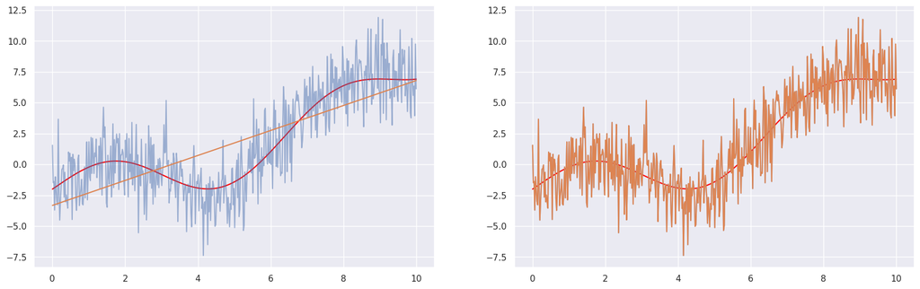

```python
fig, ax = plt.subplots(ncols=2, figsize=(20, 6))
plot(lr_reg, ax[0])
plot(dt_reg, ax[1])
```

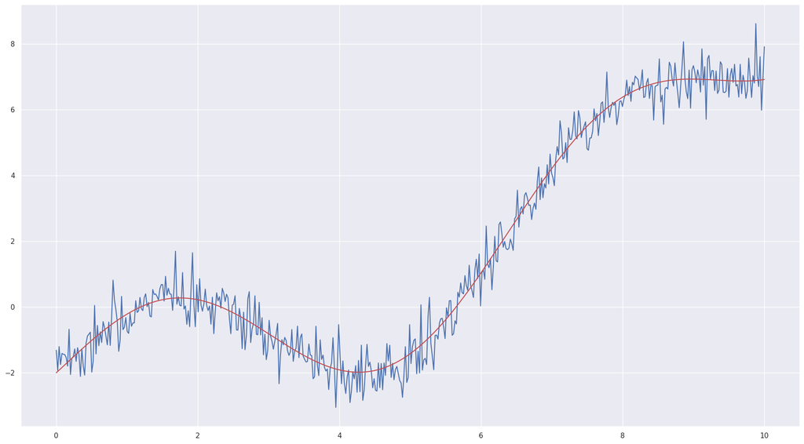

```python
x = np.linspace(0, 10, 500)
fix, ax = plt.subplots(figsize=(22, 12))
# ax.fill_between(x, 1.8 * np.sin(x) + 0.09 * x ** 2 - 5, 2.1 * np.sin(x) + 0.11 * x ** 2 + 1, alpha=0.2)
ax.plot(x, randomize(fun, x, scale=0.5))
ax.plot(x, fun(x), color="r");
```

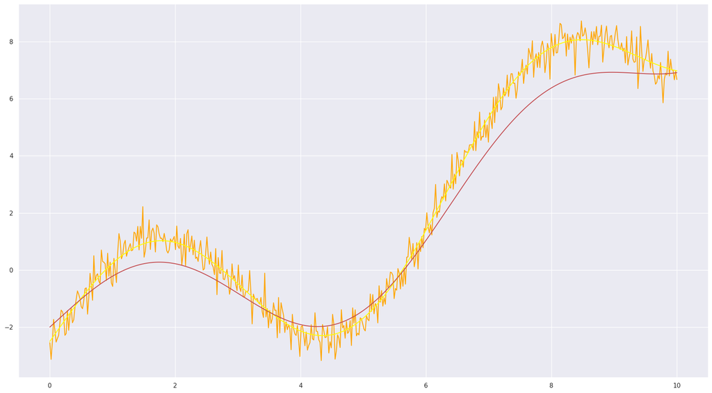

```python
def fun2(x): return 2.8 * np.sin(x) + 0.3 * x + 0.08 * x ** 2 - 2.5
fix, ax = plt.subplots(figsize=(22, 12))
# ax.fill_between(x, 1.8 * np.sin(x) + 0.09 * x ** 2 - 5, 2.1 * np.sin(x) + 0.11 * x ** 2 + 1, alpha=0.2)
ax.plot(x, randomize(fun2, x, scale=0.4), color="orange")
ax.plot(x, fun2(x), color="yellow")
ax.plot(x, fun(x), color="r");
```

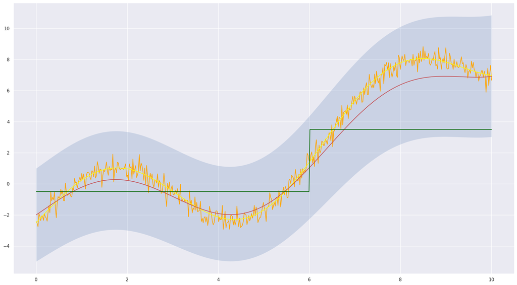

```python
fix, ax = plt.subplots(figsize=(22, 12))
ax.fill_between(x, 1.8 * np.sin(x) + 0.09 * x ** 2 - 5, 2.1 * np.sin(x) + 0.11 * x ** 2 + 1, alpha=0.2)
ax.plot(x, randomize(fun2, x, scale=0.4), color="orange")
# ax.plot(x, randomize(fun, x, scale=0.5))
ax.plot(x, fun2(x), color="yellow")
ax.plot(x, fun(x), color="r")
ax.plot(x, np.select([x<=6, x>6], [-0.5, 3.5]), color="darkgreen");
```

## Recognizing Overfitting

- Performance on your training set is much better than on your validation/test set

## Reducing Overfitting

- Collect more/different training data
- Perform (better) feature engineering
- Decrease model capacity
- Regularize the model
- Use cross validation
- Augment the training data
- Add batch normalization, dropout, ... layers
- Stop training early
- ...

```python
rng = np.random.default_rng(42)
dt_reg = DecisionTreeRegressor()
x_train = rng.uniform(size=(100, 1), low=0.0, high=10.0)
y_train = randomize(fun, x_train, scale=1.5)
y_test = randomize(fun, x_train, scale=1.5)
dt_reg.fit(x_train, y_train)
```

```
DecisionTreeRegressor()
```

```python
mae = mean_absolute_error(y_train, dt_reg.predict(x_train))
mse = mean_squared_error(y_train, dt_reg.predict(x_train))
mae, mse
```

```
(np.float64(0.0), np.float64(0.0))
```

```python
mae_test = mean_absolute_error(y_test, dt_reg.predict(x_train))
mse_test = mean_squared_error(y_test, dt_reg.predict(x_train))
mae_test, mse_test
```

```
(np.float64(1.5806173118899007), np.float64(4.365264985334807))
```

```python
fun_mae = mean_absolute_error(y_train, fun(x_train))
fun_mse = mean_squared_error(y_train, fun(x_train))
fun_mae, fun_mse
```

```
(np.float64(1.1898193262971575), np.float64(2.1588644498085032))
```

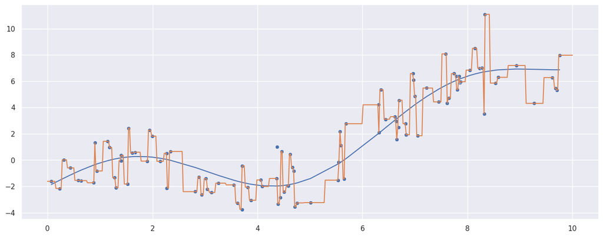

```python
fig, ax = plt.subplots(figsize=(16, 6))
sns.lineplot(x=x_train[:, 0], y=fun(x_train)[:, 0])
sns.scatterplot(x=x_train[:, 0], y=y_train[:, 0])
sns.lineplot(x=x_plot, y=dt_reg.predict(x_plot.reshape(-1, 1)));
```

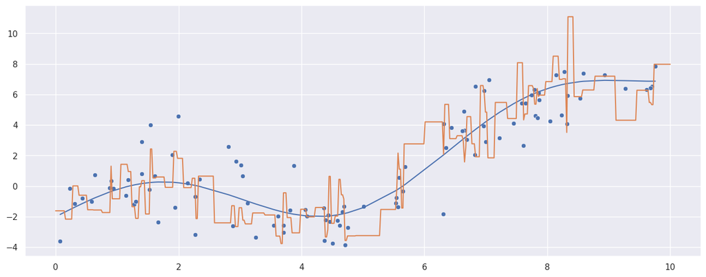

```python
fig, ax = plt.subplots(figsize=(16, 6))
sns.lineplot(x=x_train[:, 0], y=fun(x_train)[:, 0])
sns.scatterplot(x=x_train[:, 0], y=y_test[:, 0])
sns.lineplot(x=x_plot, y=dt_reg.predict(x_plot.reshape(-1, 1)));
```

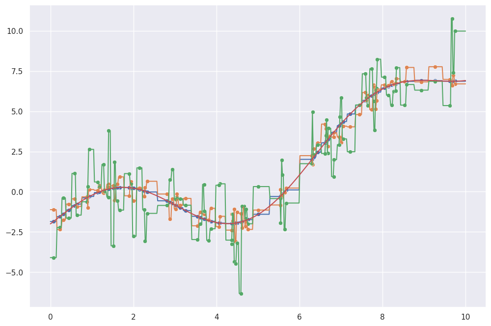

```
No randomness:      MAE = 0.10, MSE = 0.03, RMSE = 0.17
Some randomness:    MAE = 0.60, MSE = 0.51, RMSE = 0.71
Lots of randomness: MAE = 1.66, MSE = 4.31, RMSE = 2.07
```

```python
evaluate_regressor(DecisionTreeRegressor, fun)
```

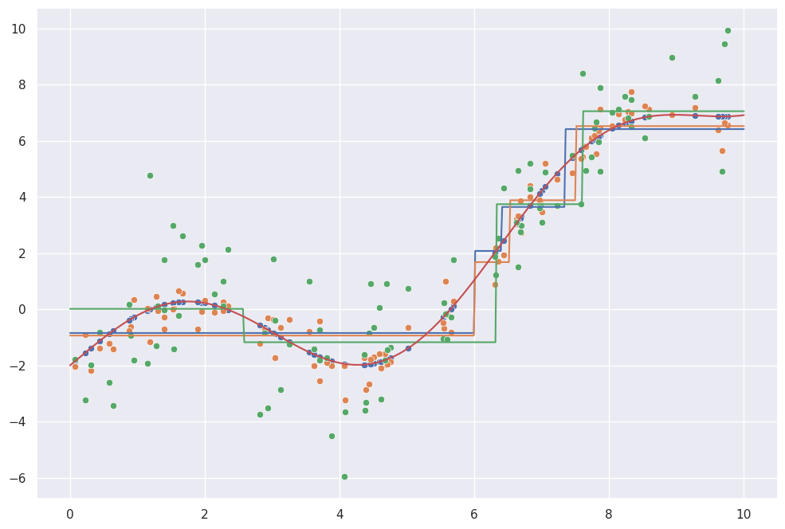

```
No randomness:      MAE = 0.74, MSE = 0.69, RMSE = 0.83
Some randomness:    MAE = 0.82, MSE = 1.00, RMSE = 1.00
Lots of randomness: MAE = 1.28, MSE = 2.75, RMSE = 1.66
```

```python
evaluate_regressor(DecisionTreeRegressor, fun, max_depth=2)
```

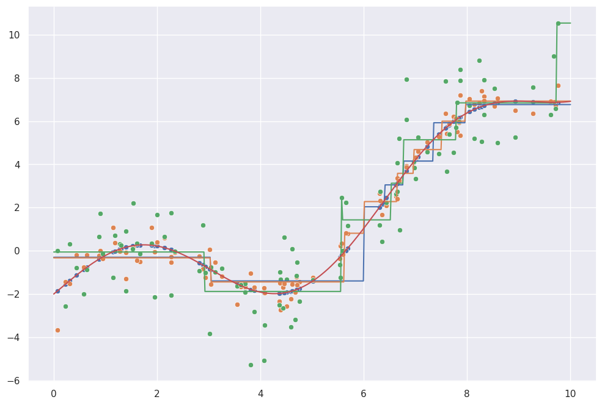

```
No randomness:      MAE = 0.52, MSE = 0.61, RMSE = 0.78
Some randomness:    MAE = 0.38, MSE = 0.22, RMSE = 0.47
Lots of randomness: MAE = 1.45, MSE = 3.21, RMSE = 1.79
```

```python
evaluate_regressor(DecisionTreeRegressor, fun, max_depth=3)
```

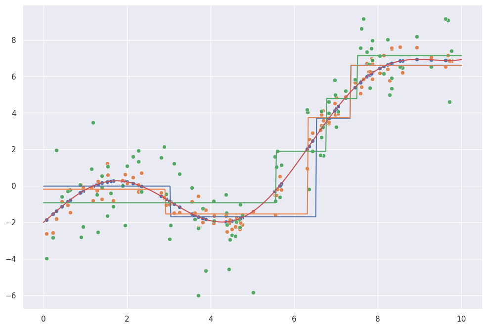

```
No randomness:      MAE = 0.80, MSE = 1.50, RMSE = 1.22
Some randomness:    MAE = 0.84, MSE = 1.28, RMSE = 1.13
Lots of randomness: MAE = 1.29, MSE = 2.89, RMSE = 1.70
```

```python
evaluate_regressor(DecisionTreeRegressor, fun, max_depth=2, criterion="absolute_error")
```

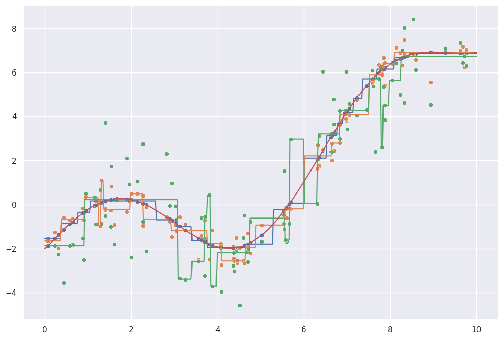

```
No randomness:      MAE = 0.17, MSE = 0.06, RMSE = 0.25
Some randomness:    MAE = 0.61, MSE = 0.56, RMSE = 0.75
Lots of randomness: MAE = 1.60, MSE = 4.08, RMSE = 2.02
```

```python
# evaluate_regressor(DecisionTreeRegressor, fun, max_leaf_nodes=20)
evaluate_regressor(DecisionTreeRegressor, fun, max_leaf_nodes=20, criterion="absolute_error")
```

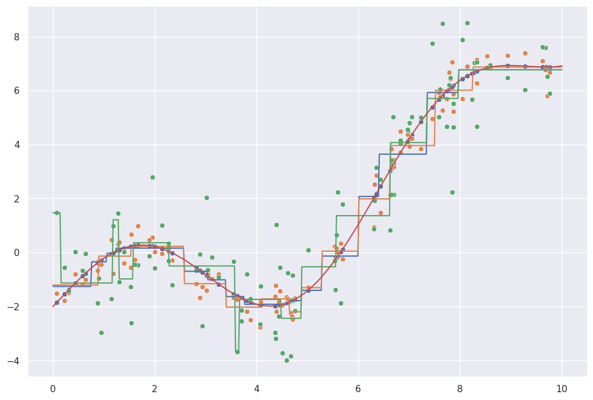

```
No randomness:      MAE = 0.27, MSE = 0.15, RMSE = 0.39
Some randomness:    MAE = 0.41, MSE = 0.25, RMSE = 0.50
Lots of randomness: MAE = 1.12, MSE = 2.23, RMSE = 1.49
```

```python
evaluate_regressor(DecisionTreeRegressor, fun, min_samples_split=16)
```

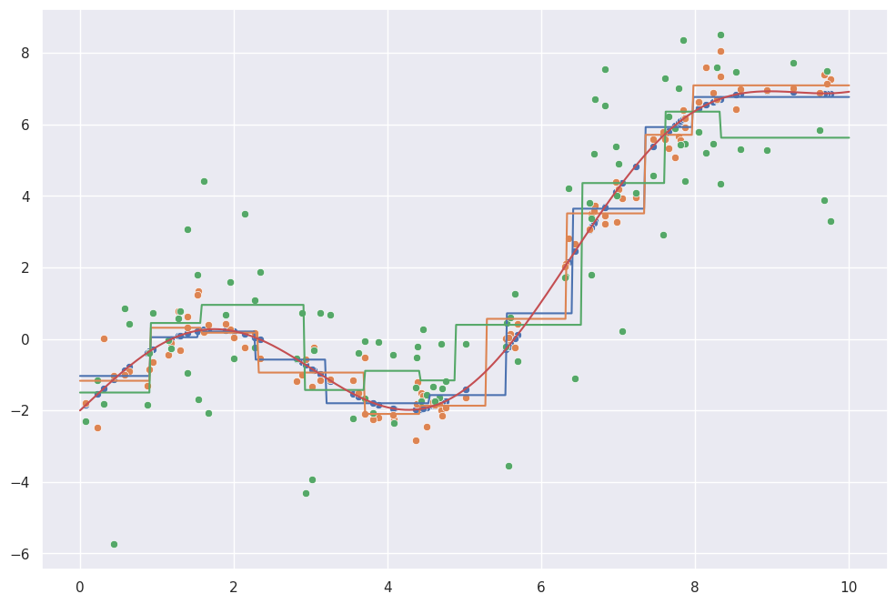

```
No randomness:      MAE = 0.30, MSE = 0.17, RMSE = 0.42
Some randomness:    MAE = 0.51, MSE = 0.41, RMSE = 0.64
Lots of randomness: MAE = 1.60, MSE = 3.93, RMSE = 1.98
```

```python
evaluate_regressor(DecisionTreeRegressor, fun, min_samples_leaf=8)
```